# Bay Wheels Data Exploration

## Preliminary Wrangling

> This dataset explores Bay Wheels trip data from January 2019 to December 2019.

```python
# import all packages and set plots to be embedded inline
import numpy as np
import pandas as pd
import matplotlib.pyplot as plt
import seaborn as sb

%matplotlib inline
```

### Data loading

```python
data_201901 = pd.read_csv('Data/201901-fordgobike-tripdata.csv')
data_201901['Month'] = 'January'
data_201902 = pd.read_csv('Data/201902-fordgobike-tripdata.csv')
data_201902['Month'] = 'February'
data_201903 = pd.read_csv('Data/201903-fordgobike-tripdata.csv')
data_201903['Month'] = 'March'
data_201904 = pd.read_csv('Data/201904-fordgobike-tripdata.csv')
data_201904['Month'] = 'April'
data_201905 = pd.read_csv('Data/201905-baywheels-tripdata.csv')
data_201905['Month'] = 'May'
data_201906 = pd.read_csv('Data/201906-baywheels-tripdata.csv')
data_201906['Month'] = 'June'
data_201907 = pd.read_csv('Data/201907-baywheels-tripdata.csv')
data_201907['Month'] = 'July'
data_201908 = pd.read_csv('Data/201908-baywheels-tripdata.csv')
data_201908['Month'] = 'August'
data_201909 = pd.read_csv('Data/201909-baywheels-tripdata.csv')
data_201909['Month'] = 'September'
data_201910 = pd.read_csv('Data/201910-baywheels-tripdata.csv')
data_201910['Month'] = 'October'
data_201911 = pd.read_csv('Data/201911-baywheels-tripdata.csv')
data_201911['Month'] = 'November'
data_201912 = pd.read_csv('Data/201912-baywheels-tripdata.csv')
data_201912['Month'] = 'December'
```

```python
# combining multiple data files
data_12months = [data_201901, data_201902, data_201903,data_201904,data_201905,data_201906,data_201907,data_201908,data_201909,data_201910,data_201911,data_201912]

data = pd.concat(data_12months)
data = data.drop(columns=['bike_share_for_all_trip','rental_access_method'])
data.to_csv('trip_data.csv',index=False)
```

```python
data_201901.head()
```

|  | duration_sec | start_time | end_time | start_station_id | start_station_name | start_station_latitude | start_station_longitude | end_station_id | end_station_name | end_station_latitude | end_station_longitude | bike_id | user_type | bike_share_for_all_trip | Month |
| --- | --- | --- | --- | --- | --- | --- | --- | --- | --- | --- | --- | --- | --- | --- | --- |
| 0 | 80825 | 2019-01-31 17:57:44.6130 | 2019-02-01 16:24:49.8640 | 229.0 | Foothill Blvd at 42nd Ave | 37.775745 | -122.213037 | 196.0 | Grand Ave at Perkins St | 37.808894 | -122.256460 | 4861 | Subscriber | No | January |
| 1 | 65900 | 2019-01-31 20:58:33.8860 | 2019-02-01 15:16:54.1730 | 4.0 | Cyril Magnin St at Ellis St | 37.785881 | -122.408915 | 134.0 | Valencia St at 24th St | 37.752428 | -122.420628 | 5506 | Subscriber | No | January |
| 2 | 62633 | 2019-01-31 18:06:52.9240 | 2019-02-01 11:30:46.5300 | 245.0 | Downtown Berkeley BART | 37.870139 | -122.268422 | 157.0 | 65th St at Hollis St | 37.846784 | -122.291376 | 2717 | Customer | No | January |
| 3 | 44680 | 2019-01-31 19:46:09.7190 | 2019-02-01 08:10:50.3180 | 85.0 | Church St at Duboce Ave | 37.770083 | -122.429156 | 53.0 | Grove St at Divisadero | 37.775946 | -122.437777 | 4557 | Customer | No | January |
| 4 | 60709 | 2019-01-31 14:19:01.5410 | 2019-02-01 07:10:51.0650 | 16.0 | Steuart St at Market St | 37.794130 | -122.394430 | 28.0 | The Embarcadero at Bryant St | 37.787168 | -122.388098 | 2100 | Customer | No | January |

```python
print(data.shape)
data.head()
```

```
(2506983, 14)
```

|  | duration_sec | start_time | end_time | start_station_id | start_station_name | start_station_latitude | start_station_longitude | end_station_id | end_station_name | end_station_latitude | end_station_longitude | bike_id | user_type | Month |
| --- | --- | --- | --- | --- | --- | --- | --- | --- | --- | --- | --- | --- | --- | --- |
| 0 | 80825 | 2019-01-31 17:57:44.6130 | 2019-02-01 16:24:49.8640 | 229.0 | Foothill Blvd at 42nd Ave | 37.775745 | -122.213037 | 196.0 | Grand Ave at Perkins St | 37.808894 | -122.256460 | 4861 | Subscriber | January |
| 1 | 65900 | 2019-01-31 20:58:33.8860 | 2019-02-01 15:16:54.1730 | 4.0 | Cyril Magnin St at Ellis St | 37.785881 | -122.408915 | 134.0 | Valencia St at 24th St | 37.752428 | -122.420628 | 5506 | Subscriber | January |
| 2 | 62633 | 2019-01-31 18:06:52.9240 | 2019-02-01 11:30:46.5300 | 245.0 | Downtown Berkeley BART | 37.870139 | -122.268422 | 157.0 | 65th St at Hollis St | 37.846784 | -122.291376 | 2717 | Customer | January |
| 3 | 44680 | 2019-01-31 19:46:09.7190 | 2019-02-01 08:10:50.3180 | 85.0 | Church St at Duboce Ave | 37.770083 | -122.429156 | 53.0 | Grove St at Divisadero | 37.775946 | -122.437777 | 4557 | Customer | January |
| 4 | 60709 | 2019-01-31 14:19:01.5410 | 2019-02-01 07:10:51.0650 | 16.0 | Steuart St at Market St | 37.794130 | -122.394430 | 28.0 | The Embarcadero at Bryant St | 37.787168 | -122.388098 | 2100 | Customer | January |

```python
data.info()
```

```
<class 'pandas.core.frame.DataFrame'>
Int64Index: 2506983 entries, 0 to 150101
Data columns (total 14 columns):
 #   Column                   Dtype
---  ------                   -----
 0   duration_sec             int64
 1   start_time               object
 2   end_time                 object
 3   start_station_id         float64
 4   start_station_name       object
 5   start_station_latitude   float64
 6   start_station_longitude  float64
 7   end_station_id           float64
 8   end_station_name         object
 9   end_station_latitude     float64
 10  end_station_longitude    float64
 11  bike_id                  int64
 12  user_type                object
 13  Month                    object
dtypes: float64(6), int64(2), object(6)
memory usage: 286.9+ MB
```

```python
data.describe()
```

|  | duration_sec | start_station_id | start_station_latitude | start_station_longitude | end_station_id | end_station_latitude | end_station_longitude | bike_id |
| --- | --- | --- | --- | --- | --- | --- | --- | --- |
| count | 2.506983e+06 | 2.426249e+06 | 2.506983e+06 | 2.506983e+06 | 2.424081e+06 | 2.506983e+06 | 2.506983e+06 | 2.506983e+06 |
| mean | 8.076483e+02 | 1.465047e+02 | 3.776506e+01 | -1.223499e+02 | 1.427044e+02 | 3.776422e+01 | -1.223459e+02 | 2.789833e+04 |
| std | 1.974714e+03 | 1.223171e+02 | 1.363698e-01 | 3.089648e-01 | 1.214296e+02 | 2.392885e-01 | 7.080417e-01 | 1.146067e+05 |
| min | 6.000000e+01 | 3.000000e+00 | 0.000000e+00 | -1.225143e+02 | 3.000000e+00 | 0.000000e+00 | -1.225143e+02 | 4.000000e+00 |
| 25% | 3.590000e+02 | 4.700000e+01 | 3.776931e+01 | -1.224130e+02 | 4.300000e+01 | 3.777003e+01 | -1.224117e+02 | 1.952000e+03 |
| 50% | 5.710000e+02 | 1.050000e+02 | 3.778053e+01 | -1.223983e+02 | 1.010000e+02 | 3.778076e+01 | -1.223981e+02 | 4.420000e+03 |
| 75% | 8.870000e+02 | 2.430000e+02 | 3.779539e+01 | -1.222914e+02 | 2.390000e+02 | 3.779587e+01 | -1.222934e+02 | 9.682000e+03 |
| max | 9.121100e+05 | 4.980000e+02 | 4.551000e+01 | 0.000000e+00 | 4.980000e+02 | 4.551000e+01 | 0.000000e+00 | 9.999410e+05 |

### What is the structure of your dataset?

> This dataset contains 2506983 data which all have details of each bike trip, including duration, start/end time, start/end station information, bike ID, and user type.

### What is/are the main feature(s) of interest in your dataset?

> I am interested in finding out the location related features to the trip durations and who would be more interested in long trips, causuals or members?

### What features in the dataset do you think will help support your investigation into your feature(s) of interest?

> I think the lantitude and longtitude information will help with the location exploration, and the duration will have support for different users' trip experience.

## Data Preparation

```python
data['duration_min'] = round(data.duration_sec/60,0)
```

```python
data.head()
```

|  | duration_sec | start_time | end_time | start_station_id | start_station_name | start_station_latitude | start_station_longitude | end_station_id | end_station_name | end_station_latitude | end_station_longitude | bike_id | user_type | Month | duration_min |
| --- | --- | --- | --- | --- | --- | --- | --- | --- | --- | --- | --- | --- | --- | --- | --- |
| 0 | 80825 | 2019-01-31 17:57:44.6130 | 2019-02-01 16:24:49.8640 | 229.0 | Foothill Blvd at 42nd Ave | 37.775745 | -122.213037 | 196.0 | Grand Ave at Perkins St | 37.808894 | -122.256460 | 4861 | Subscriber | January | 1347.0 |
| 1 | 65900 | 2019-01-31 20:58:33.8860 | 2019-02-01 15:16:54.1730 | 4.0 | Cyril Magnin St at Ellis St | 37.785881 | -122.408915 | 134.0 | Valencia St at 24th St | 37.752428 | -122.420628 | 5506 | Subscriber | January | 1098.0 |
| 2 | 62633 | 2019-01-31 18:06:52.9240 | 2019-02-01 11:30:46.5300 | 245.0 | Downtown Berkeley BART | 37.870139 | -122.268422 | 157.0 | 65th St at Hollis St | 37.846784 | -122.291376 | 2717 | Customer | January | 1044.0 |
| 3 | 44680 | 2019-01-31 19:46:09.7190 | 2019-02-01 08:10:50.3180 | 85.0 | Church St at Duboce Ave | 37.770083 | -122.429156 | 53.0 | Grove St at Divisadero | 37.775946 | -122.437777 | 4557 | Customer | January | 745.0 |
| 4 | 60709 | 2019-01-31 14:19:01.5410 | 2019-02-01 07:10:51.0650 | 16.0 | Steuart St at Market St | 37.794130 | -122.394430 | 28.0 | The Embarcadero at Bryant St | 37.787168 | -122.388098 | 2100 | Customer | January | 1012.0 |

```python
distance = []

for index, row in data.iterrows():
    coords_1 = (row.start_station_latitude, row.start_station_longitude)
    coords_2 = (row.end_station_latitude, row.end_station_longitude)
    x = round(geopy.distance.geodesic(coords_1, coords_2).km,2)
    distance.append(x)
```

```python
data['distance'] = distance
```

```python
data['Hour'] = data['start_time'].str[11:13]
```

```python
data.head()
```

|  | duration_sec | start_time | end_time | start_station_id | start_station_name | start_station_latitude | start_station_longitude | end_station_id | end_station_name | end_station_latitude | end_station_longitude | bike_id | user_type | Month | duration_min | distance | Hour |
| --- | --- | --- | --- | --- | --- | --- | --- | --- | --- | --- | --- | --- | --- | --- | --- | --- | --- |
| 0 | 80825 | 2019-01-31 17:57:44.6130 | 2019-02-01 16:24:49.8640 | 229.0 | Foothill Blvd at 42nd Ave | 37.775745 | -122.213037 | 196.0 | Grand Ave at Perkins St | 37.808894 | -122.256460 | 4861 | Subscriber | January | 1347.0 | 5.31 | 17 |
| 1 | 65900 | 2019-01-31 20:58:33.8860 | 2019-02-01 15:16:54.1730 | 4.0 | Cyril Magnin St at Ellis St | 37.785881 | -122.408915 | 134.0 | Valencia St at 24th St | 37.752428 | -122.420628 | 5506 | Subscriber | January | 1098.0 | 3.85 | 20 |
| 2 | 62633 | 2019-01-31 18:06:52.9240 | 2019-02-01 11:30:46.5300 | 245.0 | Downtown Berkeley BART | 37.870139 | -122.268422 | 157.0 | 65th St at Hollis St | 37.846784 | -122.291376 | 2717 | Customer | January | 1044.0 | 3.29 | 18 |
| 3 | 44680 | 2019-01-31 19:46:09.7190 | 2019-02-01 08:10:50.3180 | 85.0 | Church St at Duboce Ave | 37.770083 | -122.429156 | 53.0 | Grove St at Divisadero | 37.775946 | -122.437777 | 4557 | Customer | January | 745.0 | 1.00 | 19 |
| 4 | 60709 | 2019-01-31 14:19:01.5410 | 2019-02-01 07:10:51.0650 | 16.0 | Steuart St at Market St | 37.794130 | -122.394430 | 28.0 | The Embarcadero at Bryant St | 37.787168 | -122.388098 | 2100 | Customer | January | 1012.0 | 0.95 | 14 |

```python
data.info()
```

```
<class 'pandas.core.frame.DataFrame'>
Int64Index: 2506983 entries, 0 to 150101
Data columns (total 17 columns):
 #   Column                   Dtype
---  ------                   -----
 0   duration_sec             int64
 1   start_time               object
 2   end_time                 object
 3   start_station_id         float64
 4   start_station_name       object
 5   start_station_latitude   float64
 6   start_station_longitude  float64
 7   end_station_id           float64
 8   end_station_name         object
 9   end_station_latitude     float64
 10  end_station_longitude    float64
 11  bike_id                  int64
 12  user_type                object
 13  Month                    object
 14  duration_min             float64
 15  distance                 float64
 16  Hour                     int64
dtypes: float64(8), int64(3), object(6)
memory usage: 384.3+ MB
```

```python
data.to_csv('data.csv', index= False)
```

## Univariate Exploration

### Number of trips per month

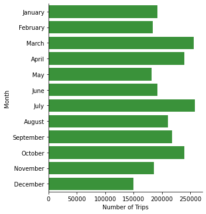

```python
color = sb.color_palette()[2]

plt.figure(figsize=[10,12]);

graph = sb.catplot(data = data, y = 'Month', kind = 'count',color = color);

graph.set_axis_labels('Number of Trips', 'Month');
```

### Number of trips per user type

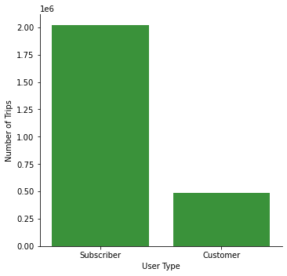

```python
plt.figure(figsize=[8,6]);

graph = sb.catplot(data = data, x = 'user_type', kind = 'count',color = color);

graph.set_axis_labels('User Type', 'Number of Trips');
```

We found subscribers are usually the frequent users, which could relate to the subscription fee or subscription bonus

### Most common start station

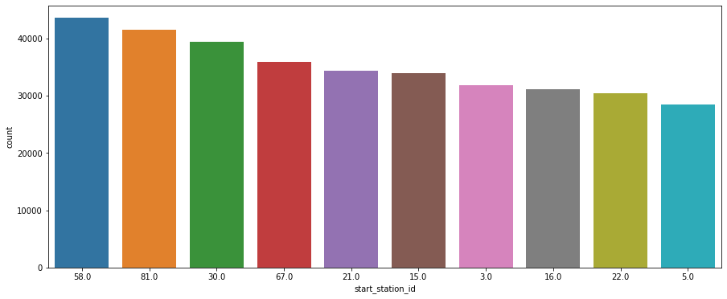

```python
plt.figure(figsize=[15,6]);

graph = sb.countplot(x='start_station_id',data=data,order=pd.value_counts(data['start_station_id']).iloc[:10].index);
```

### Most common end station

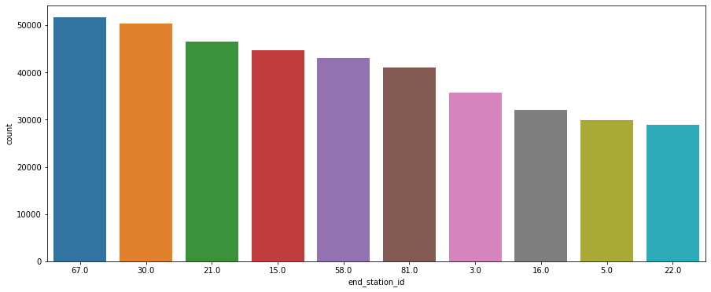

```python
plt.figure(figsize=[15,6]);

graph = sb.countplot(x='end_station_id',data=data,order=pd.value_counts(data['end_station_id']).iloc[:10].index);
```

Based on these two charts, we can assume these top ten stations are probably in the central of the city commute since the overlapping for start and end stations is very high.

## Bivariate Exploration

### Monthly average trip distance

```python
# distance plot, we found many have 0 km, we remove those value for better understanding of the trip distance
data['distance'].value_counts()
```

```
0.00        60615
1.04        23274
1.37        19924
1.31        19869
1.41        18930
            ...
12806.69        1
12803.44        1
12806.60        1
8.32            1
9.49            1
Name: distance, Length: 1123, dtype: int64
```

```python
valid_trip = data[data['distance']!=0]

monthly_average = pd.DataFrame(valid_trip.groupby('Month')['distance'].mean())

month = ['January', 'February', 'March', 'April', 'May', 'June', 'July', 'August', 'September', 'October', 'November', 'December']
monthly_average = monthly_average.reindex(month)
```

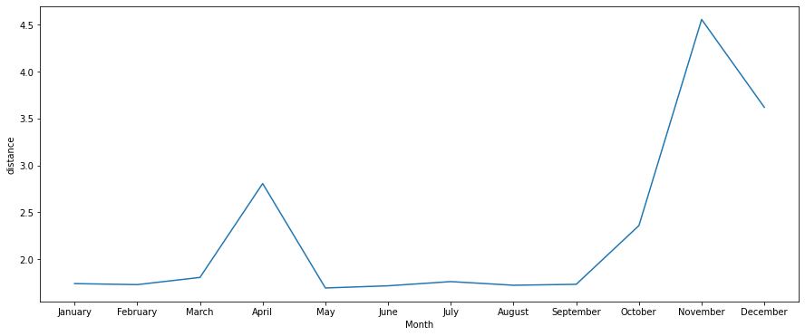

```python
plt.figure(figsize=[15,6]);
graph = sb.lineplot(data=monthly_average, x=monthly_average.index, y="distance",sort= False);
```

For this monthly average trip chart, what is different from our expectations is that average trip distance in the winter is similiar or even higher than the summer times, it will be interesting to explore further if we have more access to different data.

### Trip duration for subscriber vs. customer

```python
valid_trip.duration_min.value_counts()[:30]
```

```
6.0     192319
7.0     181685
5.0     180799
8.0     177943
4.0     162975
9.0     160786
10.0    152456
11.0    131540
12.0    121024
3.0     112507
13.0    102307
14.0     93241
15.0     78474
16.0     70687
17.0     58926
2.0      54548
18.0     52878
19.0     43160
20.0     37881
21.0     31524
22.0     27844
23.0     23132
24.0     20352
25.0     17069
26.0     15392
27.0     13090
28.0     11924
29.0     10224
30.0      8928
Name: duration_min, dtype: int64
```

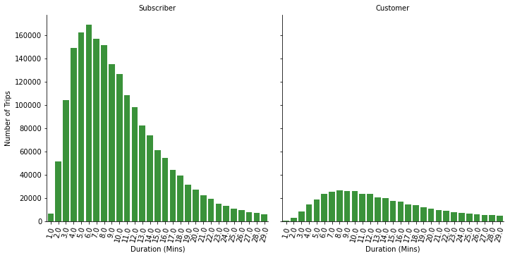

```python
plt.figure(figsize=[20, 8])

data = valid_trip.query('duration_min < 30')

graph = sb.catplot(data=data, x = 'duration_min', col='user_type', kind='count',color = color);

graph.set_axis_labels('Duration (Mins)', 'Number of Trips')
graph.set_titles('{col_name}')

graph.set_xticklabels(rotation=75);
```

We can tell from this visualization that subscribers are more frequently use the bikes and usually have shorter trips which could be considered as normal short commute for everyday.

## Multivariate Exploration

### Numeric variables relationship

```python
data.info()
```

```
<class 'pandas.core.frame.DataFrame'>
Int64Index: 2343480 entries, 6 to 150100
Data columns (total 17 columns):
 #   Column                   Dtype
---  ------                   -----
 0   duration_sec             int64
 1   start_time               object
 2   end_time                 object
 3   start_station_id         float64
 4   start_station_name       object
 5   start_station_latitude   float64
 6   start_station_longitude  float64
 7   end_station_id           float64
 8   end_station_name         object
 9   end_station_latitude     float64
 10  end_station_longitude    float64
 11  bike_id                  int64
 12  user_type                object
 13  Month                    object
 14  duration_min             float64
 15  distance                 float64
 16  Hour                     int64
dtypes: float64(8), int64(3), object(6)
memory usage: 361.8+ MB
```

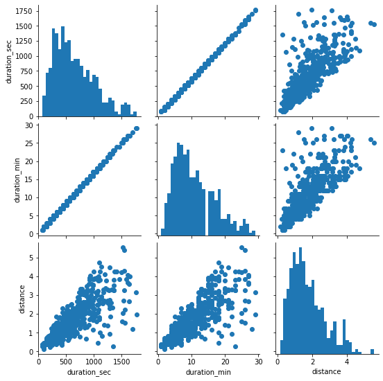

```python
numeric_vars = ['duration_sec','duration_min','distance']

samples = np.random.choice(data.shape[0], 500, replace = False)
data_samp = data.iloc[samples,:]

g = sb.PairGrid(data = data_samp, vars = numeric_vars)
g = g.map_diag(plt.hist, bins = 30);
g.map_offdiag(plt.scatter);
```

As expected, these three numeric values are highly correlated with each other.

### Monthly Distance for Customers and Subscribers

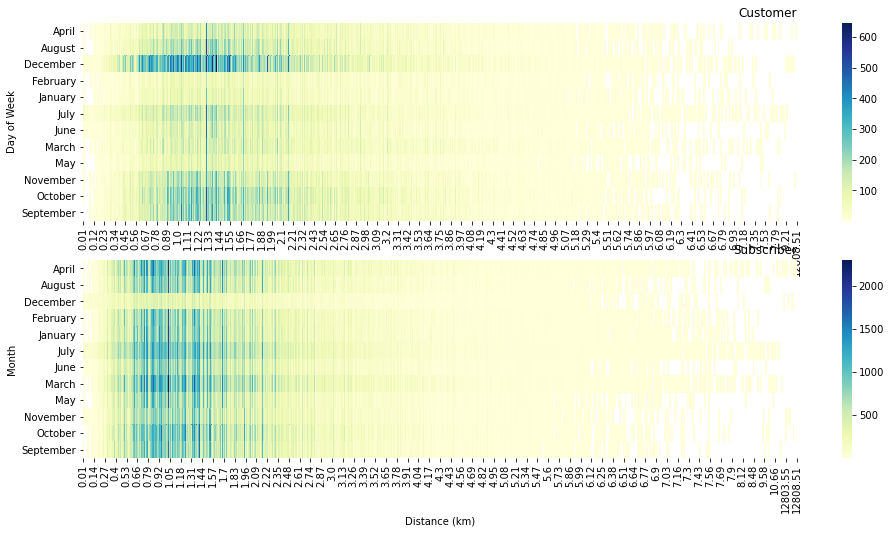

```python
plt.suptitle('Monthly Distance for Customers and Subscribers')
#fig, ax = plt.subplots(figsize=(5,5))

plt.figure(figsize = (16,8))
plt.subplot(2, 1, 1)
customers = data.query('user_type == "Customer"')
ct_counts = customers.groupby(['Month', 'distance']).size()
ct_counts = ct_counts.reset_index(name='count')
ct_counts = ct_counts.pivot(index='Month', columns='distance', values='count')
sb.heatmap(ct_counts, cmap='YlGnBu');
plt.title('Customer', loc='right');
plt.xlabel('Distance (km)');
plt.ylabel('Day of Week');

plt.subplot(2, 1, 2)
subscribers = data.query('user_type == "Subscriber"')
st_counts = subscribers.groupby(['Month', 'distance']).size()
st_counts = st_counts.reset_index(name='count')
st_counts = st_counts.pivot(index='Month', columns='distance', values='count')
sb.heatmap(st_counts, cmap='YlGnBu');
plt.title('Subscriber', loc='right');
plt.xlabel('Distance (km)');
plt.ylabel('Month');
```

From this chart, we can tell that the peak time dor customer use is in December and mostly in short distance trips as well. For subscribers, the distributions are rather even except that the December is the low month, and March and April are the months with higher uses.